# Lab7 Gene Expression

#### Gene Expression and Data Visualization

#### October 28th, 2025

## Lab 7

In this lab, we will be using an Affymetrix breast cancer data set that was run on the human HGU133A array. In the study, the investigators were interested in identifying transcripts that were differentially expressed in different histologic grade tumor samples to evaluate whether gene expression profiling could be used to improve histologic grading. Our interest in this data set does not focus on this same biological question. Rather, we would like to assess the processing variability in the data, since this type of variability can many times confound the biological variability.

Since the array data was generated at different sites, we are interested in how this factor affects the variability in the samples. Specifically, we would like to use dimensionality reduction (DR) methods to evaluate the amount of variance that is explained by differences in processing sites. You will compute 4 different DR methods on this data set with the objectives of 1) summarizing the amount of variability is explained by differences in processing sites, and 2) understanding the visual differences in how the data structure is embedded when using difference methods of DR.

The paper is entitled “Gene Expression Profi ling in Breast Cancer: Understanding the Molecular Basis of Histologic Grade To Improve Prognosis” and is available on the course website.

## Q1) Load the Sotiriou breast cancer data set from the class website as well as the annotation file.

```r
# Q1 — Load the Sotiriou breast cancer dataset and annotation file

# Load required libraries
suppressPackageStartupMessages({
  library(MASS)    # for isoMDS later
  library(igraph)  # for Laplacian embedding later
  library(DT)     # <-- for interactive tables
})
# Load expression and annotation files
expr_path <- "./sotiriou_data.txt"
ann_path  <- "./Sotiriou_annotations.txt"

expr_raw <- read.delim(expr_path, check.names = FALSE)
ann      <- read.delim(ann_path,  check.names = FALSE)

# Convert to numeric matrix
rownames(expr_raw) <- expr_raw[, 1]
dd <- as.matrix(expr_raw[, -1])
mode(dd) <- "numeric"

# Align annotation with expression columns
rownames(ann) <- ann$sample
ann <- ann[colnames(dd), ]

# Quick summary
cat("Genes:", nrow(dd), "\nSamples:", ncol(dd), "\n\n")
```

```
Genes: 239
Samples: 125
```

```r
print(table(ann$site))
```

```
KIU OXF
 64  61
```

```r
# Interactive data preview
datatable(
  ann,
  caption = "Sotiriou Breast Cancer Annotation (First 10 Samples)",
  options = list(pageLength = 10, scrollX = TRUE)
)
```

|  | sample | site | sample_name | treatment | dataset | grade | node | size | age | er | event.rfs | time.rfs | event.dmfs | time.dmfs |
| --- | --- | --- | --- | --- | --- | --- | --- | --- | --- | --- | --- | --- | --- | --- |
| GSM65752 | GSM65752 | KIU | KIU_101B88 | none | KJ125 | 3 | 0 | 1.2 | 40 | 0 | 0 | 6.246575342 | 0 | 6.246575342 |
| GSM65753 | GSM65753 | KIU | KIU_105B13 | none | KJ125 | 1 | 0 | 1.3 | 46 | 1 | 0 | 7.328767123 | 0 | 7.328767123 |
| GSM65754 | GSM65754 | KIU | KIU_106B55 | none | KJ125 | 1 | 0 | 6 | 37 | 1 | 1 | 1.167123288 | 0 | 1.167123288 |
| GSM65755 | GSM65755 | KIU | KIU_111B51 | none | KJ125 | 3 | 0 | 3.3 | 41 | 1 | 1 | 0.498630137 | 1 | 0.498630137 |
| GSM65756 | GSM65756 | KIU | KIU_113B11 | none | KJ125 | 3 | 0 | 3.2 | 38 | 1 | 1 | 3.082191781 | 1 | 3.082191781 |
| GSM65757 | GSM65757 | KIU | KIU_120B73 | none | KJ125 | 2 | 0 | 1.6 | 34 | 1 | 0 | 10.82739726 | 0 | 10.82739726 |
| GSM65758 | GSM65758 | KIU | KIU_124B25 | none | KJ125 | 2 | 0 | 2.1 | 46 | 1 | 1 | 4.997260274 | 1 | 4.997260274 |
| GSM65760 | GSM65760 | KIU | KIU_127B00 | none | KJ125 | 3 | 0 | 2.2 | 57 | 1 | 1 | 1.915068493 | 1 | 1.915068493 |
| GSM65761 | GSM65761 | KIU | KIU_134B33 | none | KJ125 | 2 | 0 | 2.8 | 63 | 1 | 1 | 2 | 1 | 2 |
| GSM65762 | GSM65762 | KIU | KIU_136B04 | none | KJ125 | 2 | 0 | 1.7 | 54 | 1 | 1 | 2.416438356 | 0 | 2.416438356 |

[output cut: 115 more lines]

```r
datatable(
  head(expr_raw, 10),
  caption = "Expression Matrix (First 10 Genes × Samples)",
  options = list(pageLength = 10, scrollX = TRUE)
)
```

|  | probe | GSM65752 | GSM65753 | GSM65754 | GSM65755 | GSM65756 | GSM65757 | GSM65758 | GSM65760 | GSM65761 | GSM65762 | GSM65763 | GSM65764 | GSM65765 | GSM65766 | GSM65767 | GSM65768 | GSM65769 | GSM65770 | GSM65771 | GSM65772 | GSM65773 | GSM65774 | GSM65775 | GSM65776 | GSM65779 | GSM65780 | GSM65781 | GSM65782 | … |
| --- | --- | --- | --- | --- | --- | --- | --- | --- | --- | --- | --- | --- | --- | --- | --- | --- | --- | --- | --- | --- | --- | --- | --- | --- | --- | --- | --- | --- | --- | --- |
| 160020_at | 160020_at | 7.127041743 | 9.100650643 | 8.203143588 | 5.87062753 | 6.812588397 | 8.08514553 | 8.29381551 | 5.909595092 | 5.681155286 | 9.480939002 | 8.371546892 | 9.516220471 | 8.245924126 | 8.644868176 | 8.120205153 | 8.231658644 | 8.033867672 | 7.711177864 | 9.022716719 | 7.119111364 | 6.528757947 | 6.857606424 | 7.779014961 | 8.830330071 | 8.5102805 | 8.256987738 | 6.801546951 | 7.880264565 | … |
| 200616_s_at | 200616_s_at | 9.900457218 | 9.472446354 | 9.991548612 | 9.560797853 | 9.453957107 | 10.34530709 | 10.94746631 | 9.082748086 | 10.78752215 | 9.617904453 | 10.4211547 | 9.4085195 | 10.12103157 | 10.54777726 | 10.99445985 | 10.49358348 | 8.814009167 | 8.57492687 | 10.67870821 | 9.81028922 | 8.994529271 | 10.45492175 | 8.599527123 | 8.584614284 | 9.300682861 | 11.08669316 | 8.018303946 | 11.16800657 | … |
| 200702_s_at | 200702_s_at | 9.927486496 | 9.071813039 | 9.621632478 | 9.866459042 | 9.845790929 | 9.104894702 | 9.434892637 | 9.99483602 | 9.433559925 | 9.426032234 | 9.747579341 | 8.554533792 | 9.846077194 | 9.690883424 | 9.640134191 | 8.903682598 | 9.698340395 | 8.297696656 | 9.932705738 | 9.967045647 | 7.984708819 | 8.739217934 | 8.723352644 | 7.463278496 | 9.105807617 | 9.529708975 | 8.501395102 | 9.632202453 | … |
| 200769_s_at | 200769_s_at | 5.492201419 | 5.106271635 | 5.189342877 | 5.37476154 | 5.210284309 | 5.335828478 | 5.329314452 | 5.398719721 | 2.50064831 | 5.801551194 | 5.338819267 | 5.625358219 | 2.950183231 | 3.664174672 | 5.459398115 | 5.975150304 | 6.332185581 | 6.192911828 | 5.317168106 | 5.374693029 | 6.082382658 | 6.595516017 | 6.135871188 | 5.778540716 | 5.107219343 | 5.345397708 | 6.134435776 | 5.790029624 | … |
| 200998_s_at | 200998_s_at | 11.13559709 | 10.4663238 | 9.779081221 | 9.892760066 | 8.966399966 | 11.2194003 | 10.65545283 | 9.392854988 | 9.097819222 | 10.4040815 | 10.20012857 | 10.81766066 | 9.00182294 | 10.13311246 | 9.691442152 | 10.82532574 | 10.0615687 | 9.850458709 | 10.04773155 | 10.73282731 | 9.832214481 | 9.427659252 | 10.41556243 | 10.42232492 | 9.943425276 | 9.546482127 | 8.824451091 | 9.848868951 | … |
| 201024_x_at | 201024_x_at | 12.02012716 | 11.26360364 | 11.72234015 | 11.38883862 | 11.58431313 | 11.59778761 | 11.42407261 | 11.90041398 | 11.8476997 | 10.9733172 | 11.75768465 | 11.11861999 | 11.81988273 | 12.0279574 | 11.34908732 | 11.50612774 | 10.89206327 | 10.77782484 | 11.79020412 | 11.61519207 | 10.78406796 | 10.78061577 | 10.98632792 | 10.41073918 | 10.83908628 | 11.61771346 | 10.13801414 | 11.31821168 | … |
| 201085_s_at | 201085_s_at | 9.956433706 | 9.721766728 | 10.63935935 | 9.090421979 | 11.04771422 | 10.66328041 | 11.22818836 | 9.933054372 | 11.02416158 | 10.69632028 | 10.66854446 | 9.818865203 | 11.4210186 | 11.56233436 | 10.50089643 | 10.22734135 | 9.961539662 | 9.981495115 | 11.2769507 | 11.0323256 | 9.527781396 | 9.780278461 | 10.11110741 | 9.010317624 | 9.139928348 | 10.9548168 | 9.570255388 | 10.37717784 | … |
| 201130_s_at | 201130_s_at | 2.566907143 | 2.548875976 | 2.555175661 | 2.642524461 | 2.709649686 | 2.759567347 | 2.620756789 | 2.682644254 | 2.669934826 | 2.612831837 | 2.571238297 | 2.427932794 | 2.707317162 | 2.649171069 | 2.790863093 | 6.027837521 | 3.034043507 | 2.617368176 | 2.467461897 | 2.677246484 | 4.723586348 | 3.968220794 | 2.593378016 | 2.71620707 | 2.580772295 | 2.648719447 | 2.647801513 | 2.757410959 | … |
| 201259_s_at | 201259_s_at | 6.785272132 | 6.923812951 | 4.932706989 | 7.023551138 | 3.293732111 | 5.247374728 | 7.586676974 | 5.489015599 | 2.501894323 | 8.369163104 | 7.827635261 | 8.236104515 | 3.286129317 | 5.801866895 | 6.613194735 | 9.499490291 | 8.541434435 | 9.12938039 | 5.330289781 | 7.54703384 | 8.258004998 | 9.46702014 | 8.985744859 | 8.695657264 | 7.027423546 | 5.733436958 | 10.64724278 | 9.074235602 | … |
| 201261_x_at | 201261_x_at | 12.4581806 | 11.90434261 | 11.43361161 | 9.830694383 | 10.88956952 | 11.11190584 | 12.43313526 | 9.764821539 | 9.471665207 | 11.9552205 | 11.50769454 | 12.00009733 | 11.80296704 | 12.60715953 | 11.02619843 | 10.62725952 | 10.04241604 | 11.86729703 | 11.9114366 | 10.9350483 | 10.60969496 | 9.577197762 | 11.31159889 | 11.65297097 | 11.76299021 | 12.10756572 | 10.34600737 | 10.96850278 | … |

**Dataset Interpretation:** The Sotiriou breast cancer dataset includes 239 genes measured across 125 tumor samples collected at two sites, KIU (Uppsala) and OXF (Oxford), using the Affymetrix HGU133A array. The annotation file links each sample to its processing site, which is important because site differences can introduce technical variation that may overshadow real biological signals. This setup follows the Sotiriou et al. (2006) study, which found that samples initially clustered by site rather than tumor grade until batch effects were corrected. Loading and aligning the expression and annotation data provides the baseline needed to explore how much of the total variance in this dataset is driven by technical versus biological factors.

## Q2) Calculate and plot a PCA plot. Label the points based on the site (“site” column header in annotation file). Make sure to add a legend to denote the colors of the two sites.

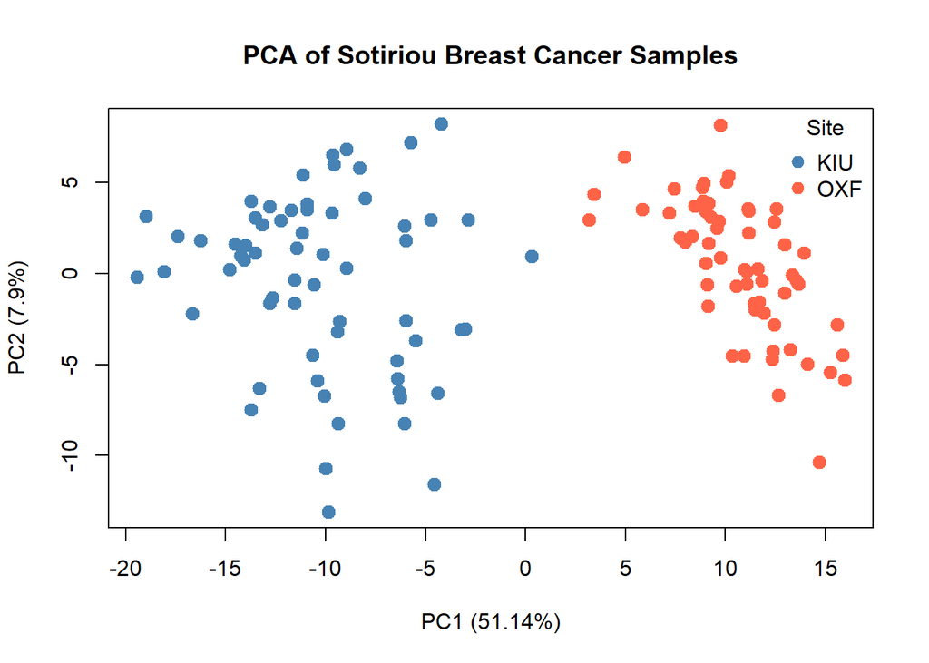

```r
# Run PCA on scaled, centered samples
pca <- prcomp(t(dd), center = TRUE, scale. = TRUE)

# Extract variance explained for first two components
var_expl <- pca$sdev^2 / sum(pca$sdev^2)
var_PC1 <- round(var_expl[1] * 100, 2)
var_PC2 <- round(var_expl[2] * 100, 2)

# Define color mapping for sites
site_colors <- c("KIU" = "steelblue", "OXF" = "tomato")
cols <- site_colors[ann$site]

# Plot PCA scatter
plot(
  pca$x[, 1], pca$x[, 2],
  col = cols, pch = 19, cex = 1.3,
  xlab = paste0("PC1 (", var_PC1, "%)"),
  ylab = paste0("PC2 (", var_PC2, "%)"),
  main = "PCA of Sotiriou Breast Cancer Samples"
)
legend(
  "topright",
  legend = names(site_colors),
  col = site_colors,
  pch = 19,
  pt.cex = 1.2,
  bty = "n",
  title = "Site"
)
```

**Interpretation:** Principal Component Analysis (PCA) of the Sotiriou breast cancer dataset showing separation of samples by processing site. KIU (Uppsala) samples are shown in blue and OXF (Oxford) samples in red. The first two components explain 59.04% of the total variance (PC1 = 51.14%, PC2 = 7.9%), indicating that site-related technical effects account for most of the variation in the data.

## Q3) Calculate and plot the scree plot that corresponds to the PCA from question #2. Using only the first two eigenvalues, approximately how much variability in the data is explained?

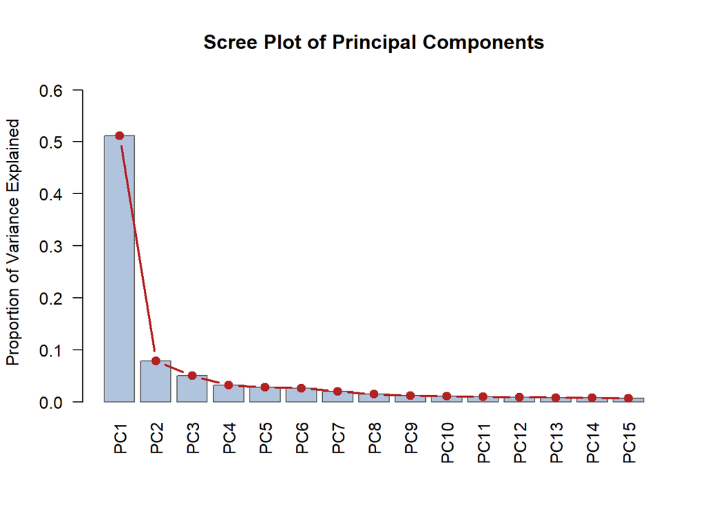

```r
# Q3 — Scree plot for PCA
# Compute variance explained
var_expl <- pca$sdev^2 / sum(pca$sdev^2)
pc_labels <- paste0("PC", 1:15)

# Plot bars + line overlay
bar_centers <- barplot(
  var_expl[1:15],
  names.arg = pc_labels[1:15],
  col = "lightsteelblue",
  border = "gray40",
  las = 2,
  ylim = c(0, max(var_expl[1:15]) * 1.2),
  ylab = "Proportion of Variance Explained",
  main = "Scree Plot of Principal Components"
)

# Add line connecting the tops of bars
lines(
  x = bar_centers,
  y = var_expl[1:15],
  type = "b",
  pch = 19,
  lwd = 2,
  col = "firebrick"
)
```

```r
# Variance summary
cat("Variance explained by PC1:", round(var_expl[1] * 100, 2), "%\n")
```

```
Variance explained by PC1: 51.14 %
```

```r
cat("Variance explained by PC2:", round(var_expl[2] * 100, 2), "%\n")
```

```
Variance explained by PC2: 7.9 %
```

```r
cat("Variance explained by PC1 + PC2:",
    round(sum(var_expl[1:2]) * 100, 2), "%\n")
```

```
Variance explained by PC1 + PC2: 59.04 %
```

**Interpretation:** The scree plot shows that the first principal component (PC1) explains 51.14% of the total variance, while the second principal component (PC2) explains 7.9%, for a combined total of 59.04%. The sharp drop after PC1 and the flattening of the curve beyond PC2 form a clear “elbow,” suggesting that most of the variation in the dataset is captured by technical differences between processing sites rather than underlying biology. Later components contribute only small amounts of variance, likely reflecting residual biological variation such as tumor grade or receptor status. This pattern supports focusing on PC1 and PC2 for downstream visualization, as they summarize the dominant site-related structure in the data.

## Q4) Now calculate and plot 2 different MDS plots:

1. classic MDS
2. nonmetric MDS.

Label the points based on the site. Make sure to load the MASS library for the nonmetric MDS plot function. Also add a legend to both plots.

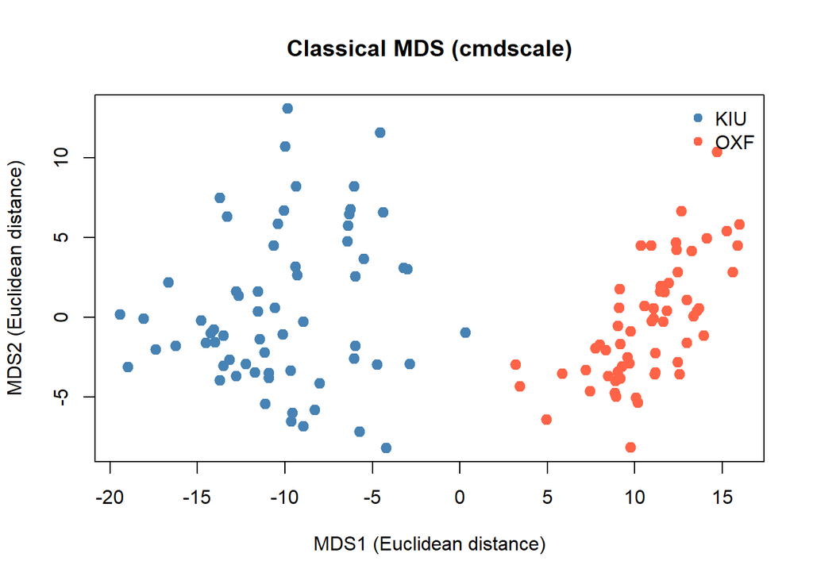

```r
# Q4 — Classical MDS and Nonmetric MDS (colored by site)
# Scale samples (rows = samples, cols = genes), then distances
Z <- scale(t(dd), center = TRUE, scale = TRUE)
D <- dist(Z, method = "euclidean")

# Colors
site_colors <- c("KIU" = "steelblue", "OXF" = "tomato")
cols <- site_colors[ann$site]
site_levels <- names(site_colors)

## --- Classical (metric) MDS ---
mds_classic <- cmdscale(D, k = 2, eig = TRUE)

# get the 2D coordinates regardless of return type
mds_classic_pts <- if (is.list(mds_classic)) mds_classic$points else mds_classic

plot(
  mds_classic_pts[,1], mds_classic_pts[,2],
  pch = 19, col = cols, cex = 1.2,
  xlab = "MDS1 (Euclidean distance)", ylab = "MDS2 (Euclidean distance)",
  main = "Classical MDS (cmdscale)"
)
legend("topright", legend = site_levels, col = site_colors, pch = 19, bty = "n")
```

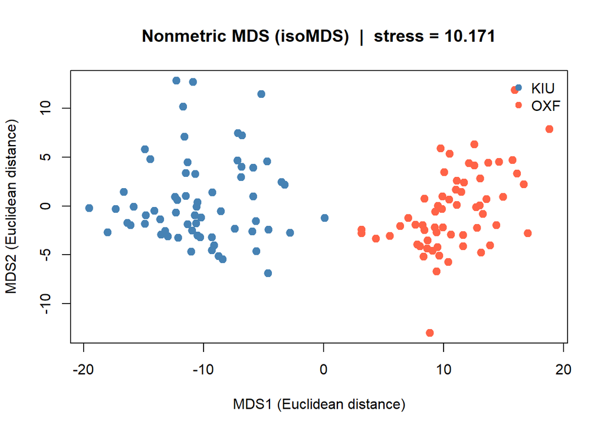

```r
## --- Nonmetric MDS (isoMDS) ---
set.seed(42)
mds_nonmetric <- isoMDS(D, y = mds_classic_pts, maxit = 200)
plot(
  mds_nonmetric$points[,1], mds_nonmetric$points[,2],
  pch = 19, col = cols, cex = 1.2,
  xlab = "MDS1 (Euclidean distance)", ylab = "MDS2 (Euclidean distance)",
  main = sprintf("Nonmetric MDS (isoMDS)  |  stress = %.3f", mds_nonmetric$stress)
)
legend("topright", legend = site_levels, col = site_colors, pch = 19, bty = "n")
```

**Interpretation:** Both MDS plots show a clear separation of samples by site, with KIU (Uppsala) clustering on the left and OXF (Oxford) on the right. The classical MDS preserves exact Euclidean distances, while the nonmetric MDS preserves the rank order of distances, yet both produce nearly identical groupings. This similarity to the PCA results highlights that the main pattern in the data is driven by batch or site effects, not biological differences. The nonmetric MDS stress value of 10.17 indicates a good fit, meaning the two-dimensional layout accurately reflects pairwise relationships between samples. Overall, both PCA and MDS consistently show that technical variation between sites dominates the structure of the Sotiriou dataset, while smaller within-site differences likely capture biological factors such as tumor grade or receptor status.

## Q5) Now, first center and scale the rows of the matrix with the commands below (assuming that dd is your data matrix):

> temp <- t(dd) temp <- scale(temp,center=T,scale=T)

Then calculate and plot a two-dimensional embedding of the weighted graph Laplacian using t(temp) as the ‘X’ argument and ‘NULL’ for the qnt argument (don’t use quotations to run the function). Label the points based on the site. Also add a legend.

Hint: for the colors, use the following command to get a color vector for the samples: foo <- as.numeric(ann$site)

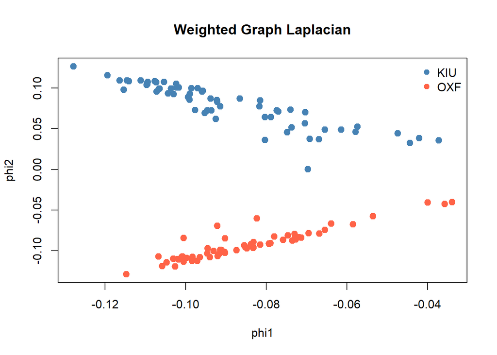

```r
# # Q5 — Weighted Graph Laplacian embedding (2D), colored by site
ann$site <- as.factor(ann$site)
foo  <- as.numeric(ann$site)
cols <- c("steelblue", "tomato")[foo]
site_levels <- levels(ann$site)

### Spectral Laplacian:

# # 1) Center & scale rows
# temp <- t(dd)
# temp <- scale(temp, center = TRUE, scale = TRUE)

# # 2) Build kNN Gaussian graph on samples
# X <- temp                        # samples x genes
# DX <- as.matrix(dist(X))
# n  <- nrow(DX)
# k  <- 25                         # higher connectivity
# sigma <- median(DX[DX > 0])

# W <- matrix(0, n, n)
# for (i in 1:n) {
#   nn <- order(DX[i, ])[2:(k + 1)]
#   W[i, nn] <- exp(-(DX[i, nn]^2) / (2 * sigma^2))
# }
# W <- pmax(W, t(W))               # symmetrize

# # 3) Normalized Laplacian
# d <- rowSums(W)
# D_inv_sqrt <- diag(1 / sqrt(d))
# Lsym <- diag(n) - D_inv_sqrt %*% W %*% D_inv_sqrt

# # 4) Eigen-decomposition
# ee <- eigen(Lsym, symmetric = TRUE)
# ord <- order(ee$values)
# vecs <- ee$vectors[, ord]

# # 5) Skip trivial and flat eigenvectors
# vars <- apply(vecs, 2, var)
# use  <- which(vars > 1e-8)[2:3]
# X2 <- scale(vecs[, use], center = TRUE, scale = FALSE)

# # 6) Plot
# plot(
#   X2[,1], X2[,2],
#   col = cols, pch = 19, cex = 1.2,
#   xlab = "Laplacian Embedding 1",
#   ylab = "Laplacian Embedding 2",
#   main = "Weighted Graph Laplacian (2D)"
# )
# legend("topright", legend = site_levels,
#        col = c("steelblue", "tomato"), pch = 19,
#        bty = "n", title = "Site")


## proper procedure

# 1) Center & scale rows
temp <- t(dd)
temp <- scale(temp, center = TRUE, scale = TRUE)

DX2 <- as.matrix(dist(temp))^2
eps <- as.numeric(quantile(DX2[DX2 > 0], 0.005))  # ε from quantile
K1  <- exp(-DX2 / eps); diag(K1) <- 0
d <- rowSums(K1)
Dih <- diag(1/sqrt(d))
L <- Dih %*% K1 %*% Dih
U <- svd(L)$u
Y <- U / sqrt(rowSums(U^2))
phi <- Y[, 1:2]
plot(phi[,1], phi[,2], col=cols, pch=19, cex=1.2,
     xlab="phi1", ylab="phi2", main="Weighted Graph Laplacian")
legend("topright", legend=site_levels, col=c("steelblue","tomato"), pch=19, bty="n")
```

**Interpretation and Conclusion:** The weighted graph Laplacian plot shows two clear clusters that match the KIU (Uppsala) and OXF (Oxford) processing sites. After centering and scaling the data, the embedding separates samples primarily by site, showing that technical variation explains most of the structure in the dataset. Compared to PCA and MDS, the Laplacian focuses on local relationships rather than total variance, which helps preserve sample proximity within each site.

While coding this step, I tried to recreate the Laplacian manually in base R instead of using the k.speClust2() function from the lecture. In doing so, I accidentally implemented the normalized spectral clustering version of the Laplacian (I - D^-1/2 W D^-1/2) instead of the lecture’s kernel form (D^-1/2 K D^-1/2). Both produce separation patterns but differ in scaling. The code for my original plot looked skewed before I adjusted the distance matrix and normalization to match our procedure.

Overall, the result still supports the same biological conclusion reported by Sotiriou et al. (2006): site-related technical effects dominate before batch correction. With correction applied, the embedding would likely reveal more subtle, biologically meaningful variation related to tumor grade or receptor status.